# Clase 17. SVAR con restricciones de largo plazo — Blanchard y Quah (1989)

Series de Tiempo | Semestre 2027-I | FC-UNAM

Benjamin Oliva & Luis Gerardo Ruiz González

October 2026

## ¿Qué aprenderemos hoy?

Replicamos en R la Figura 2 de Blanchard y Quah (1989, *AER*), el ejemplo clásico de identificación con **restricciones de largo plazo**: un choque de demanda puede mover el PIB en el corto plazo, pero no tiene efecto sobre su nivel en el largo plazo; sólo el choque de oferta lo tiene. Esta versión sustituye a `GO_BQ1989.m` (VAR Toolbox de Cesa-Bianchi en MATLAB) y reproduce sus resultados.

Al terminar esta clase deberás poder:

1. Explicar por qué una restricción sobre la **suma** de las respuestas identifica los choques estructurales
2. Estimar un SVAR de largo plazo con `vars::BQ()` y obtener la respuesta del **nivel** del PIB acumulando la respuesta de su tasa de crecimiento
3. Contrastar este esquema con la identificación recursiva de la clase anterior

**Datos:** `BQ1989_Data.xlsx` (trimestral, EE.UU., 1948T2 a 1987T4, 159 observaciones)

## 1. La idea de Blanchard y Quah

El VAR tiene dos variables: el crecimiento del PIB, $\Delta y_t$, y la tasa de desempleo, $u_t$. Como en la identificación recursiva, los errores reducidos son $e_t = B\varepsilon_t$ con $BB' = \Sigma_e$, y nos falta $n(n-1)/2 = 1$ restricción. Ahora la ponemos sobre el **efecto acumulado** de los choques. La representación MA del VAR es

$$X_t = \mu + \sum_{h=0}^{\infty} \Psi_h B\,\varepsilon_{t-h}, \qquad
C(1) \equiv \sum_{h=0}^{\infty} \Psi_h B = (I - A_1 - \dots - A_p)^{-1}
B .$$

El elemento $(1, j)$ de $C(1)$ es la suma de todas las respuestas del **crecimiento** del PIB al choque $j$, es decir, el efecto de largo plazo sobre el **nivel** del PIB. Blanchard y Quah suponen:

- **Choque de oferta** ($\varepsilon_1$, productividad): puede afectar el nivel del PIB para siempre.
- **Choque de demanda** ($\varepsilon_2$): su efecto sobre el nivel del PIB desaparece, $C(1)_{12} = 0$.

Esa restricción hace a $C(1)$ triangular inferior. Como $C(1)C(1)' = F\Sigma_e F'$ con $F = (I - A_1 - \dots - A_p)^{-1}$, se obtiene $C(1) = \text{chol}(F\Sigma_e F')$ y, de ahí, $B = F^{-1} C(1)$. Es lo que hace `vars::BQ()` y también la opción `VARopt.ident = 'long'` del Toolbox de MATLAB.

> El desempleo es estacionario, de modo que ningún choque tiene efecto permanente sobre él; la restricción sólo dice algo sobre el PIB.

## 2. Paquetes y datos

```r
if (!require(pacman)) install.packages("pacman")
```

```r
library(pacman)
p_load("readxl", "vars", "dplyr", "tidyr", "ggplot2", "knitr")

# La primera fila del Excel tiene nombres largos y la segunda los cortos (y, u):
bq <- read_excel("BQ1989_Data.xlsx", skip = 1)
names(bq)[1] <- "fecha"
bq <- bq %>%
  mutate(across(c(y, u), as.numeric))

head(bq)
```

```
## # A tibble: 6 × 3
##   fecha        y       u
##   <chr>    <dbl>   <dbl>
## 1 1948Q2  0.854  -0.142
## 2 1948Q3  0.0121 -0.0662
## 3 1948Q4 -0.0851 -0.0232
## 4 1949Q1 -2.08    0.786
## 5 1949Q2 -1.49    1.96
## 6 1949Q3 -0.149   2.77
```

```r
nrow(bq)
```

```
## [1] 159
```

| Variable | Descripción | Transformación (ya aplicada en el archivo) |
| --- | --- | --- |
| `fecha` | Trimestre (`1948Q2`, …, `1987Q4`) | — |
| `y` | Crecimiento trimestral (diferencia logarítmica × 100) del producto real de EE.UU. El artículo usa el PNB (*GNP*); el Excel lo etiqueta como *GDP growth* | Se le resta su media por separado en 1948T2-1973T4 y en 1974T1-1987T4: la productividad se desaceleró después del primer choque petrolero (3.62% contra 2.43% anual) |
| `u` | Tasa de desempleo, en puntos porcentuales | Se le resta una tendencia lineal (el desempleo promedio subió poco a poco en la posguerra) |

Las dos series tienen media cero, como en el artículo original:

```r
round(colMeans(bq[, c("y", "u")]), 4)
```

```
##     y     u
## 0e+00 3e-04
```

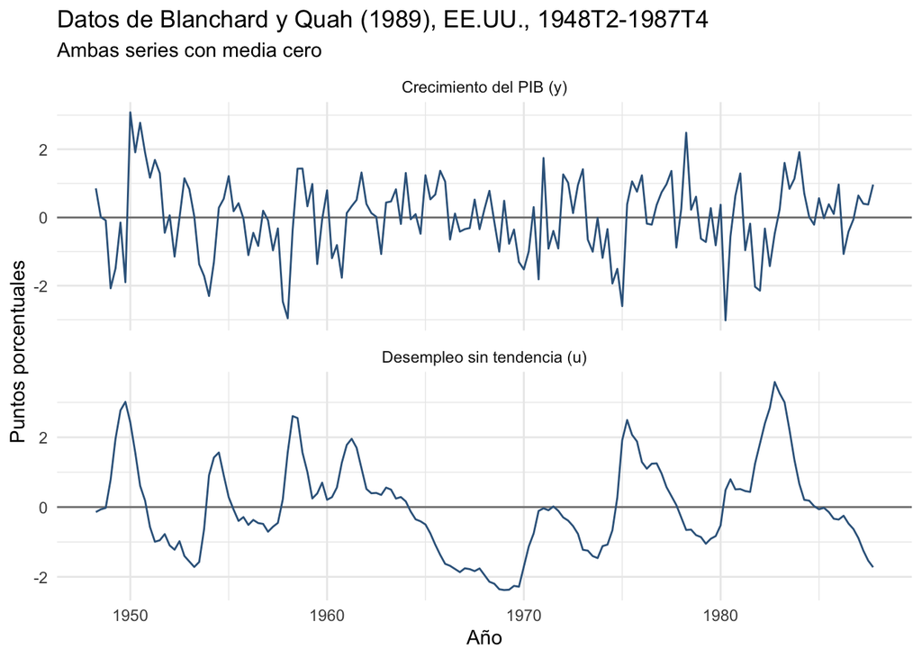

```r
bq %>%
  mutate(t = seq(1948.25, by = 0.25, length.out = n())) %>%
  pivot_longer(c(y, u)) %>%
  mutate(name = recode(name, y = "Crecimiento del PIB (y)", u = "Desempleo sin tendencia (u)")) %>%
  ggplot(aes(x = t, y = value)) +
  geom_hline(yintercept = 0, colour = "gray50") +
  geom_line(colour = "steelblue4") +
  facet_wrap(~ name, ncol = 1, scales = "free_y") +
  labs(title = "Datos de Blanchard y Quah (1989), EE.UU., 1948T2-1987T4",
       subtitle = "Ambas series con media cero",
       x = "Año", y = "Puntos porcentuales") +
  theme_minimal()
```

## 3. VAR reducido

Igual que en el artículo y en `GO_BQ1989.m`: 8 rezagos y constante.

```r
var.bq <- vars::VAR(bq[, c("y", "u")], p = 8, type = "const")
summary(var.bq)$covres
```

```
##            y          u
## y  0.8697462 -0.1771674
## u -0.1771674  0.0916771
```

```r
max(roots(var.bq))
```

```
## [1] 0.8559425
```

## 4. Identificación de largo plazo con `BQ()`

```r
svar.bq <- BQ(var.bq)
svar.bq
```

```
##
## SVAR Estimation Results:
## ========================
##
##
## Estimated contemporaneous impact matrix:
##        y       u
## y 0.0746 -0.9296
## u 0.2198  0.2082
##
## Estimated identified long run impact matrix:
##          y     u
## y 0.518601 0.000
## u 0.008335 4.043
```

```r
# Matriz de efectos de largo plazo C(1): el cero arriba de la diagonal es la restricción
round(svar.bq$LRIM, 4)
```

```
##        y      u
## y 0.5186 0.0000
## u 0.0083 4.0433
```

```r
# Comprobación de la fórmula de la Sección 1: B = F^{-1} C(1)
A.suma <- Reduce(`+`, Acoef(var.bq))
F.inf  <- solve(diag(2) - A.suma)
all.equal(unname(solve(F.inf) %*% svar.bq$LRIM), unname(svar.bq$B))
```

```
## [1] TRUE
```

Cholesky normaliza la diagonal de $C(1)$ a valores positivos, y con esa convención el choque de demanda sale **contractivo**: en el impacto baja el crecimiento del PIB (-0.93) y sube el desempleo (0.21). Blanchard y Quah presentan un choque de demanda **expansivo** (que sube el PIB y baja el desempleo); para eso basta cambiar el signo de la segunda columna de $B$, igual que hace `-IR(:,:,2)` en el código de MATLAB. Las restricciones de identificación nunca fijan el signo de un choque: sólo su dirección.

## 5. Replicación de la Figura 2

La IRF de `y` es la respuesta del **crecimiento** del PIB. La del **nivel** del PIB es su suma acumulada.

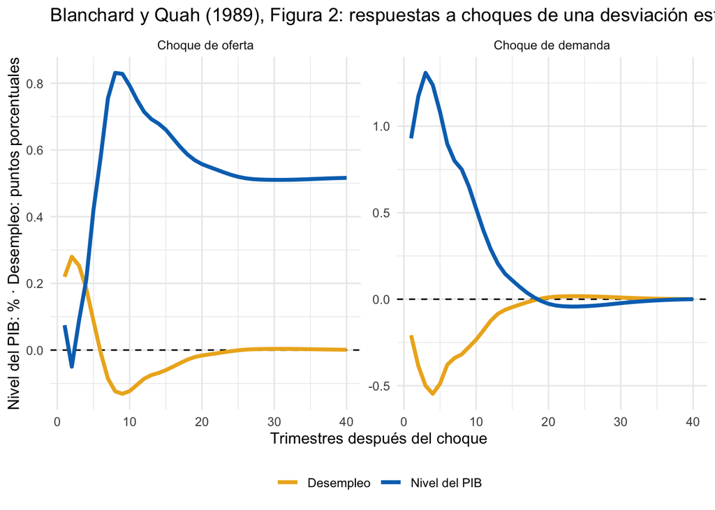

```r
H <- 40
ir.bq <- vars::irf(svar.bq, n.ahead = H - 1, boot = FALSE)

# ir.bq$irf$y: respuestas (columnas y, u) al choque 1 (oferta)
# ir.bq$irf$u: respuestas (columnas y, u) al choque 2 (demanda)
fig2 <- bind_rows(
  data.frame(trimestre = 1:H, choque = "Choque de oferta",
             `Nivel del PIB` = cumsum(ir.bq$irf$y[, "y"]),
             Desempleo       = ir.bq$irf$y[, "u"], check.names = FALSE),
  data.frame(trimestre = 1:H, choque = "Choque de demanda",
             `Nivel del PIB` = cumsum(-ir.bq$irf$u[, "y"]),
             Desempleo       = -ir.bq$irf$u[, "u"], check.names = FALSE)) %>%
  pivot_longer(c(`Nivel del PIB`, Desempleo), names_to = "variable") %>%
  mutate(choque = factor(choque, levels = c("Choque de oferta", "Choque de demanda")))

ggplot(fig2, aes(x = trimestre, y = value, colour = variable)) +
  geom_hline(yintercept = 0, linetype = "dashed") +
  geom_line(linewidth = 1.3) +
  facet_wrap(~ choque, scales = "free_y") +
  scale_colour_manual(values = c("Nivel del PIB" = "#0072BD", "Desempleo" = "#EDB120")) +
  labs(x = "Trimestres después del choque",
       y = "Nivel del PIB: % · Desempleo: puntos porcentuales", colour = NULL,
       title = "Blanchard y Quah (1989), Figura 2: respuestas a choques de una desviación estándar") +
  theme_minimal() +
  theme(legend.position = "bottom")
```

```r
# Valores en trimestres seleccionados (comparables con BQ_Replication.pdf, generado en MATLAB)
fig2 %>%
  filter(trimestre %in% c(1, 2, 3, 5, 9, 17, 40)) %>%
  mutate(value = round(value, 3)) %>%
  pivot_wider(names_from = c(choque, variable), values_from = value) %>%
  kable()
```

| trimestre | Choque de oferta_Nivel del PIB | Choque de oferta_Desempleo | Choque de demanda_Nivel del PIB | Choque de demanda_Desempleo |
| --- | --- | --- | --- | --- |
| 1 | 0.075 | 0.220 | 0.930 | -0.208 |
| 2 | -0.050 | 0.280 | 1.173 | -0.385 |
| 3 | 0.089 | 0.253 | 1.308 | -0.500 |
| 5 | 0.421 | 0.087 | 1.082 | -0.489 |
| 9 | 0.828 | -0.131 | 0.651 | -0.276 |
| 17 | 0.609 | -0.039 | 0.038 | -0.018 |
| 40 | 0.516 | 0.001 | 0.000 | 0.000 |

Los números coinciden con los del Toolbox de MATLAB (`BQ_Replication.pdf`): el PIB responde a la oferta con 0.075 en el impacto, alcanza un máximo cercano a 0.83 hacia el trimestre 9 y se estabiliza en 0.52; a la demanda, sube a 1.31 en el trimestre 3 y regresa a cero.

**Lectura.**

- **Oferta.** El efecto sobre el nivel del PIB crece durante unos dos años y se vuelve permanente. El desempleo **sube** al principio: si la productividad aumenta y la demanda tarda en ajustarse, se necesita menos trabajo para producir lo mismo.
- **Demanda.** El PIB y el desempleo se mueven en espejo (ley de Okun), alcanzan su máximo entre 2 y 4 trimestres y desaparecen hacia los 5 años. Ese regreso a cero no es un resultado: es el **supuesto** de identificación.

## 6. Bandas de confianza

Para el PIB necesitamos las bandas de la respuesta **acumulada** (el nivel), y para el desempleo las de la respuesta sin acumular, así que pedimos los dos bootstraps. Los percentiles de una suma acumulada no son la suma de los percentiles: por eso no basta con acumular las bandas a mano.

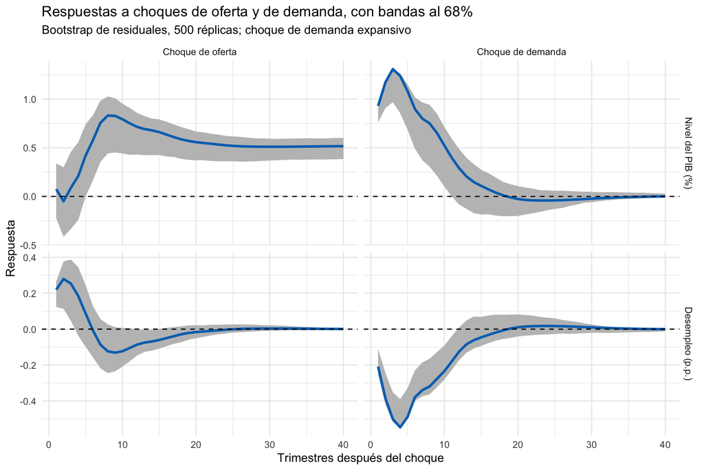

```r
set.seed(1989)
boot.nivel <- vars::irf(svar.bq, response = "y", n.ahead = H - 1, boot = TRUE,
                        runs = 500, ci = 0.68, cumulative = TRUE)
boot.u     <- vars::irf(svar.bq, response = "u", n.ahead = H - 1, boot = TRUE,
                        runs = 500, ci = 0.68)

# Arma un data frame para un choque y una variable. signo = -1 voltea el choque
# de demanda para que sea expansivo, como en la Figura 2 (al voltear, las bandas se intercambian).
banda <- function(obj, choque, var, signo, etq.choque, etq.var) {
  est <- signo * obj$irf[[choque]][, var]
  b1  <- signo * obj$Lower[[choque]][, var]
  b2  <- signo * obj$Upper[[choque]][, var]
  data.frame(trimestre = 1:H, choque = etq.choque, variable = etq.var,
             est = est, inf = pmin(b1, b2), sup = pmax(b1, b2))
}

df.boot <- bind_rows(
  banda(boot.nivel, "y", "y",  1, "Choque de oferta",  "Nivel del PIB (%)"),
  banda(boot.u,     "y", "u",  1, "Choque de oferta",  "Desempleo (p.p.)"),
  banda(boot.nivel, "u", "y", -1, "Choque de demanda", "Nivel del PIB (%)"),
  banda(boot.u,     "u", "u", -1, "Choque de demanda", "Desempleo (p.p.)")) %>%
  mutate(choque   = factor(choque, levels = c("Choque de oferta", "Choque de demanda")),
         variable = factor(variable, levels = c("Nivel del PIB (%)", "Desempleo (p.p.)")))

ggplot(df.boot, aes(x = trimestre)) +
  geom_ribbon(aes(ymin = inf, ymax = sup), fill = "gray75") +
  geom_line(aes(y = est), colour = "#0072BD", linewidth = 1.1) +
  geom_hline(yintercept = 0, linetype = "dashed") +
  facet_grid(variable ~ choque, scales = "free_y") +
  labs(title = "Respuestas a choques de oferta y de demanda, con bandas al 68%",
       subtitle = "Bootstrap de residuales, 500 réplicas; choque de demanda expansivo",
       x = "Trimestres después del choque", y = "Respuesta") +
  theme_minimal()
```

La banda del nivel del PIB ante el choque de oferta no incluye al cero después de unos cinco trimestres: el efecto permanente es significativo. Ante el choque de demanda, el efecto sobre el PIB se va a cero por construcción, y su banda se cierra en el largo plazo.

## 7. Descomposición de varianza

```r
fevd.bq <- fevd(svar.bq, n.ahead = H)
round(fevd.bq$y[c(1, 4, 8, 12, 20, 40), ], 3)
```

```
##          y     u
## [1,] 0.006 0.994
## [2,] 0.055 0.945
## [3,] 0.137 0.863
## [4,] 0.134 0.866
## [5,] 0.134 0.866
## [6,] 0.135 0.865
```

```r
round(fevd.bq$u[c(1, 4, 8, 12, 20, 40), ], 3)
```

```
##          y     u
## [1,] 0.527 0.473
## [2,] 0.233 0.767
## [3,] 0.160 0.840
## [4,] 0.167 0.833
## [5,] 0.175 0.825
## [6,] 0.175 0.825
```

Las columnas son la proporción de la varianza del error de pronóstico explicada por el choque de oferta (columna `y`) y por el de demanda (columna `u`). Con esta identificación, la demanda explica casi toda la varianza del **crecimiento** del PIB a corto plazo (la oferta mueve sobre todo su nivel de largo plazo, que se acumula poco a poco). En el desempleo, la oferta explica la mitad de la varianza en el impacto, pero a partir del primer año la demanda explica más de tres cuartas partes.

## Ejercicios

1. Estima un VAR recursivo con las mismas variables y el orden $(y, u)$ usando `vars::irf(var.bq, ortho = TRUE)`. Compara las respuestas con las de la Sección 5: ¿qué restricción impone cada esquema y en qué horizonte?
2. Repite la estimación con 4 y con 12 rezagos. ¿Qué tan sensible es la respuesta del nivel del PIB al choque de oferta? Blanchard y Quah discuten esta sensibilidad en la Sección III del artículo (`BQ1989_Paper.pdf`).
3. Elimina la corrección del cambio de media de 1973: suma a `y` la diferencia de medias entre los subperiodos (o, más sencillo, usa sólo la muestra 1948-1973) y vuelve a estimar. ¿Por qué un error en la tendencia contamina precisamente la restricción de largo plazo?